# Tutorial on Gene Expression and Network Analysis

Jeong-Eun Lee, Katja Nowick, and Deisy M. Gysi

#### Required packages

Please install the following packages before you start this tutorial:

- `DESeq2`: https://bioconductor.org/packages/release/bioc/html/DESeq2.html
- `edgeR`: https://bioconductor.org/packages/3.8/bioc/html/edgeR.html
- `biomaRt`: https://bioconductor.org/packages/release/bioc/html/biomaRt.html
- `topGO`: https://bioconductor.org/packages/3.8/bioc/html/topGO.html
- `Rgraphviz`: https://bioconductor.org/packages/release/bioc/html/Rgraphviz.html
- `wTO`: https://cran.r-project.org/web/packages/wTO/index.html
- `CoDiNA`: https://cran.r-project.org/web/packages/CoDiNA/index.html

#### Tutorial files

Please download tutorial files (.html) from blackboard/Kursmaterial. Files needed for tutorials are located in the `files` directory.

# Short background for the dataset

We will work with a dataset produced by [Snyder-Mackler et al. 2016](https://www.science.org/doi/10.1126/science.aah3580). They investigated immune responses in rhesus macaque groups. The study included several groups of macaques. Each group consistent of five individuals of different ranks. They investigated whether the immune response depends on the rank of an individual.

RNA of blood cells from each individual was sequenced with RNA-Seq on the Illumina platform. Reads were mapped to the rhesus macaque genome and counted to obtain gene expression data in form of raw counts per gene. We will use that dataset to calculate differential gene expression and co-expression networks.  
Read in your data.

[figure not shown]

Experimental paradigm

# Setup the read count metrices

Let’s load the tutorial data.

```r
readcounts=read.table("files/Tutorial_macaques_readcounts.txt", header=TRUE, row.names=1, sep="\t", stringsAsFactors=FALSE)
dim(readcounts)
```

```
## [1] 32386    50
```

```r
head(readcounts)
```

|  | SRR3660629 | SRR3660630 | SRR3660632 | SRR3660633 | SRR3660636 | SRR3660637 | SRR3660640 | SRR3660641 | SRR3660642 | SRR3660643 | SRR3660644 | SRR3660645 | SRR3660646 | SRR3660649 | SRR3660650 | SRR3660651 | SRR3660652 | SRR3660654 | SRR3660655 | SRR3660659 | SRR3660660 | SRR3660661 | SRR3660665 | SRR3660666 | SRR3660668 | SRR3660669 | SRR3660670 | SRR3660671 | SRR3660672 | … |
| --- | --- | --- | --- | --- | --- | --- | --- | --- | --- | --- | --- | --- | --- | --- | --- | --- | --- | --- | --- | --- | --- | --- | --- | --- | --- | --- | --- | --- | --- | --- |
| ENSMMUG00000005947 | 0 | 0 | 1 | 4 | 1 | 2 | 6 | 4 | 3 | 1 | 1 | 0 | 0 | 9 | 9 | 3 | 2 | 0 | 1 | 0 | 1 | 2 | 7 | 8 | 0 | 0 | 1 | 1 | 1 | … |
| ENSMMUG00000015800 | 643 | 574 | 284 | 498 | 404 | 559 | 371 | 332 | 336 | 449 | 284 | 668 | 548 | 702 | 830 | 378 | 478 | 664 | 642 | 294 | 582 | 343 | 306 | 304 | 206 | 335 | 401 | 366 | 138 | … |
| ENSMMUG00000015802 | 185 | 215 | 135 | 188 | 107 | 108 | 119 | 62 | 67 | 76 | 47 | 133 | 173 | 166 | 131 | 125 | 151 | 90 | 101 | 70 | 130 | 109 | 91 | 72 | 51 | 86 | 49 | 72 | 33 | … |
| ENSMMUG00000015804 | 33 | 25 | 21 | 50 | 72 | 78 | 34 | 23 | 17 | 12 | 19 | 18 | 48 | 28 | 58 | 30 | 47 | 41 | 33 | 21 | 26 | 27 | 17 | 18 | 15 | 15 | 16 | 11 | 8 | … |
| ENSMMUG00000022525 | 15 | 10 | 17 | 9 | 26 | 32 | 10 | 7 | 17 | 5 | 7 | 1 | 32 | 21 | 25 | 16 | 29 | 14 | 12 | 9 | 14 | 0 | 11 | 14 | 5 | 18 | 14 | 1 | 2 | … |
| ENSMMUG00000008350 | 4 | 0 | 1 | 0 | 2 | 0 | 0 | 1 | 2 | 2 | 1 | 0 | 0 | 0 | 0 | 3 | 0 | 0 | 0 | 0 | 1 | 0 | 8 | 0 | 1 | 0 | 0 | 0 | 0 | … |

```r
coldata=read.table("files/Tutorial_macaques_ids.txt", header=TRUE, row.names=1, sep="\t", stringsAsFactors=FALSE)
dim(coldata)
```

```
## [1] 50  4
```

```r
head(coldata)
```

|  | subject_id | condition | study_group | rank |
| --- | --- | --- | --- | --- |
| SRR3660629 | RAc8 | LPS | VBB_SGE2 | 4 |
| SRR3660630 | RAc8 | NC | VBB_SGE2 | 4 |
| SRR3660632 | RCw10 | LPS | Cw10_SGE2 | 1 |
| SRR3660633 | RCw10 | NC | Cw10_SGE2 | 1 |
| SRR3660636 | REg12 | LPS | Fq9_SGE2 | 3 |
| SRR3660637 | REg12 | NC | Fq9_SGE2 | 3 |

# Differential Gene Expression

The input files for the differential gene expression analysis are count matrices after RNA-seq workflow, e.g figure below until **counting**. We now are going to run **differential gene expression analysis** in this tutorial by using two packages, `DEseq2` and `edgeR.` `DESeq2` is a tool to test for differential expression by use of negative binomial generalized linear models; the estimates of dispersion and logarithmic fold changes incorporate data-driven prior distributions. Another commonly used package for calculating differential gene expression is `edgeR.` It uses empirical Bayes estimation and exact tests based on the negative binomial distribution to call differentially expressed genes. Both packages also provide their own tutorial pages, [DESeq2](http://bioconductor.org/packages/devel/bioc/vignettes/DESeq2/inst/doc/DESeq2.html) and [edgeR](http://bioconductor.org/packages/devel/bioc/vignettes/edgeR/inst/doc/edgeRUsersGuide.pdf), including more details. If interested, please visit their tutorial pages :)

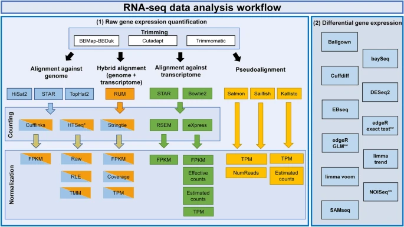

RNA-seq analysis workflow and tools

## DESeq

Let’s start with `DEseq2` by loading the library

```r
library("DESeq2")
```

The conditions treatment vs. control (LPS vs. NC) need to be defined as factors for the comparison. The reference (control) in this example is “NC”.

```r
coldata$condition = factor(coldata$condition)
```

Alternatively, you could have programmed: `coldata$condition = relevel(coldata$condition, ref = 'NC')` to achieve the same thing.

Make a `DESeqDataSet` object and look at it. It will hold the count information for each gene for each sample.

```r
dds=DESeqDataSetFromMatrix(countData = readcounts, colData = coldata, design = ~ condition)
dds
```

```
## class: DESeqDataSet
## dim: 32386 50
## metadata(1): version
## assays(1): counts
## rownames(32386): ENSMMUG00000005947 ENSMMUG00000015800 ...
##   ENSMMUG00000042591 ENSMMUG00000026105
## rowData names(0):
## colnames(50): SRR3660629 SRR3660630 ... SRR3660707 SRR3660708
## colData names(4): subject_id condition study_group rank
```

### Pre-filtering

Pre-filter genes with very low expression to reduce noise and the memory size. Here we will remove all genes with lower than 10 reads in total across all samples.

```r
keep = rowSums(counts(dds)) >= 10
dds = dds[keep,]
dds
```

```
## class: DESeqDataSet
## dim: 21391 50
## metadata(1): version
## assays(1): counts
## rownames(21391): ENSMMUG00000005947 ENSMMUG00000015800 ...
##   ENSMMUG00000048985 ENSMMUG00000049032
## rowData names(0):
## colnames(50): SRR3660629 SRR3660630 ... SRR3660707 SRR3660708
## colData names(4): subject_id condition study_group rank
```

### Note on factor levels

To specify the factors for the comparison use the function `factor()`. In this first example, we will compare NC vs. LPS.

```r
dds$condition = factor(dds$condition, levels = c("NC","LPS"))
```

### Differential expression analysis

The function `DESeq()` implements all steps from normalization to the comparison: The first step is always normalization. It estimates the effective library size to normalize for it (`estimateSizeFactors`). Imagine, a gene has the same number of counts in two samples, but the library size (total number of reads) was twice as high in the first sample. Then we would conclude that the gene was higher expressed in the second sample.

The core assumption for calculating the dispersion (`estimateDispersions`) is that the mean is a good predictor of the variance, i.e., that genes with a similar expression level also have similar variance across replicates.

Then differential expression will be calculated using the (default) Wald test. This is followed by (per default) Benjamini-Hochberg adjustment of p-values.

This will take less than one minute.

```r
dds = DESeq(dds)
```

```
## -- replacing outliers and refitting for 153 genes
## -- DESeq argument 'minReplicatesForReplace' = 7
## -- original counts are preserved in counts(dds)
```

```r
result = results(dds)
result
```

```
## log2 fold change (MLE): condition LPS vs NC
## Wald test p-value: condition LPS vs NC
## DataFrame with 21391 rows and 6 columns
##                     baseMean log2FoldChange     lfcSE        stat    pvalue
##                    <numeric>      <numeric> <numeric>   <numeric> <numeric>
## ENSMMUG00000005947   3.23429    2.58189e-01  0.515566 0.500787882 0.6165204
## ENSMMUG00000015800 452.51457    8.47337e-05  0.123196 0.000687796 0.9994512
## ENSMMUG00000015802 106.99731    3.06692e-02  0.165957 0.184802275 0.8533841
## ENSMMUG00000015804  26.82127    1.94069e-01  0.225282 0.861446985 0.3889919
## ENSMMUG00000022525  13.33049    5.41057e-01  0.319593 1.692957148 0.0904636
## ...                      ...            ...       ...         ...       ...
## ENSMMUG00000041270  0.485931     -0.4049651  0.764135  -0.5299656  0.596136
## ENSMMUG00000043278  0.628620     -0.6322486  0.784070  -0.8063674  0.420031
## ENSMMUG00000036864  1.005056      0.9361236  0.635777   1.4724082  0.140911
## ENSMMUG00000048985  0.234933      0.9500236  1.804879   0.5263641  0.598635
## ENSMMUG00000049032  0.323819     -0.0880175  1.340474  -0.0656615  0.947647
##                         padj
##                    <numeric>
## ENSMMUG00000005947  0.935336
## ENSMMUG00000015800  0.999940
## ENSMMUG00000015802  0.980834
## ENSMMUG00000015804  0.842199
## ENSMMUG00000022525  0.469716
## ...                      ...
## ENSMMUG00000041270        NA
## ENSMMUG00000043278        NA
## ENSMMUG00000036864  0.580537
## ENSMMUG00000048985        NA
## ENSMMUG00000049032        NA
```

To display what the column names mean use:

```r
mcols(result)$description
```

```
## [1] "mean of normalized counts for all samples"
## [2] "log2 fold change (MLE): condition LPS vs NC"
## [3] "standard error: condition LPS vs NC"
## [4] "Wald statistic: condition LPS vs NC"
## [5] "Wald test p-value: condition LPS vs NC"
## [6] "BH adjusted p-values"
```

To reduce some noise, you can shrink the results. The shrinkage will be performed based on the effect size. Information on shrunken log2 fold changes (LFC) will be added to the result table. Here we will save this into a new table.

This will take less 1-2 minutes.

```r
resultLFC = lfcShrink(dds, coef="condition_LPS_vs_NC", type="normal")
```

```
## using 'normal' for LFC shrinkage, the Normal prior from Love et al (2014).
##
## Note that type='apeglm' and type='ashr' have shown to have less bias than type='normal'.
## See ?lfcShrink for more details on shrinkage type, and the DESeq2 vignette.
## Reference: https://doi.org/10.1093/bioinformatics/bty895
```

```r
resultLFC
```

```
## log2 fold change (MAP): condition LPS vs NC
## Wald test p-value: condition LPS vs NC
## DataFrame with 21391 rows and 6 columns
##                     baseMean log2FoldChange     lfcSE        stat    pvalue
##                    <numeric>      <numeric> <numeric>   <numeric> <numeric>
## ENSMMUG00000005947   3.23429    1.23076e-01  0.247609 0.500787882 0.6165204
## ENSMMUG00000015800 452.51457    7.98039e-05  0.116027 0.000687796 0.9994512
## ENSMMUG00000015802 106.99731    2.75780e-02  0.149225 0.184802275 0.8533841
## ENSMMUG00000015804  26.82127    1.60798e-01  0.186706 0.861446985 0.3889919
## ENSMMUG00000022525  13.33049    3.81501e-01  0.225689 1.692957148 0.0904636
## ...                      ...            ...       ...         ...       ...
## ENSMMUG00000041270  0.485931     -0.1204733  0.225897  -0.5299656  0.596136
## ENSMMUG00000043278  0.628620     -0.1705459  0.223280  -0.8063674  0.420031
## ENSMMUG00000036864  1.005056      0.3484391  0.240800   1.4724082  0.140911
## ENSMMUG00000048985  0.234933      0.0657264  0.126525   0.5263641  0.598635
## ENSMMUG00000049032  0.323819     -0.0111288  0.161188  -0.0656615  0.947647
##                         padj
##                    <numeric>
## ENSMMUG00000005947  0.935336
## ENSMMUG00000015800  0.999940
## ENSMMUG00000015802  0.980834
## ENSMMUG00000015804  0.842199
## ENSMMUG00000022525  0.469716
## ...                      ...
## ENSMMUG00000041270        NA
## ENSMMUG00000043278        NA
## ENSMMUG00000036864  0.580537
## ENSMMUG00000048985        NA
## ENSMMUG00000049032        NA
```

Summary of the results:

```r
summary(result)
```

```
##
## out of 21389 with nonzero total read count
## adjusted p-value < 0.1
## LFC > 0 (up)       : 1125, 5.3%
## LFC < 0 (down)     : 482, 2.3%
## outliers [1]       : 0, 0%
## low counts [2]     : 2490, 12%
## (mean count < 1)
## [1] see 'cooksCutoff' argument of ?results
## [2] see 'independentFiltering' argument of ?results
```

Ordering of the results by adjusted p-value and picking the most significant genes. Here we will count how many genes have an adjusted p-value of smaller than 0.1 or 0.05, respectively.

```r
resultOrdered = result[order(result$pvalue),]
sum(result$padj < 0.1, na.rm=TRUE)
```

```
## [1] 1607
```

```r
sum(result$padj < 0.05, na.rm=TRUE)
```

```
## [1] 1295
```

Filtering of genes with False Discovery Rate (FDR) smaller than 0.05 and assigning them to a new object:

```r
result005 = results(dds, alpha=0.05)
summary(result005)
```

```
##
## out of 21389 with nonzero total read count
## adjusted p-value < 0.05
## LFC > 0 (up)       : 954, 4.5%
## LFC < 0 (down)     : 333, 1.6%
## outliers [1]       : 0, 0%
## low counts [2]     : 2076, 9.7%
## (mean count < 1)
## [1] see 'cooksCutoff' argument of ?results
## [2] see 'independentFiltering' argument of ?results
```

### Exploring results

`plotMA()` is used for plotting log2 Fold changes vs. mean expression values (baseMean) for all genes. Genes with p<0.1 are shown in blue Points with smaller or larger values than the y-axis are shown as triangles.

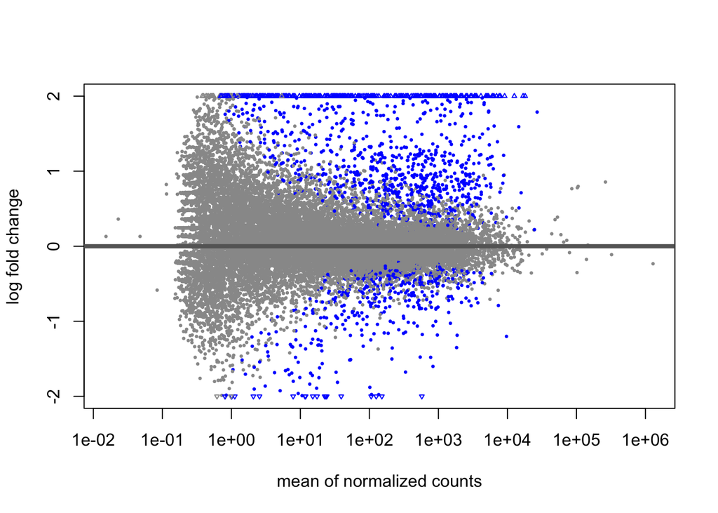

```r
plotMA(result, ylim=c(-2,2))
```

When the shrunken results are plotted with `plotMA()`, you can see that the noise from lowly expressed genes is reduced.

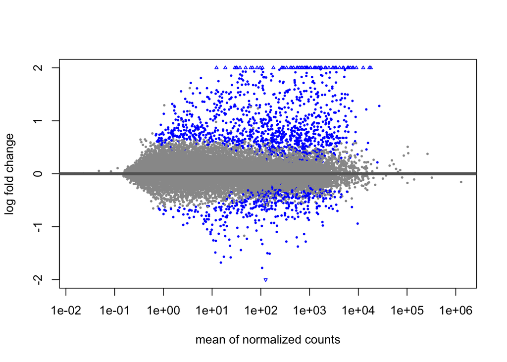

```r
plotMA(resultLFC, ylim=c(-2,2))
```

Results for individual genes of interest can also be plotted. For example, we can plot the gene with the lowest adjusted p-value. In this plot, counts are normalized by sequencing depth and a pseudocount of 1/2 is added to allow for log scale plotting.

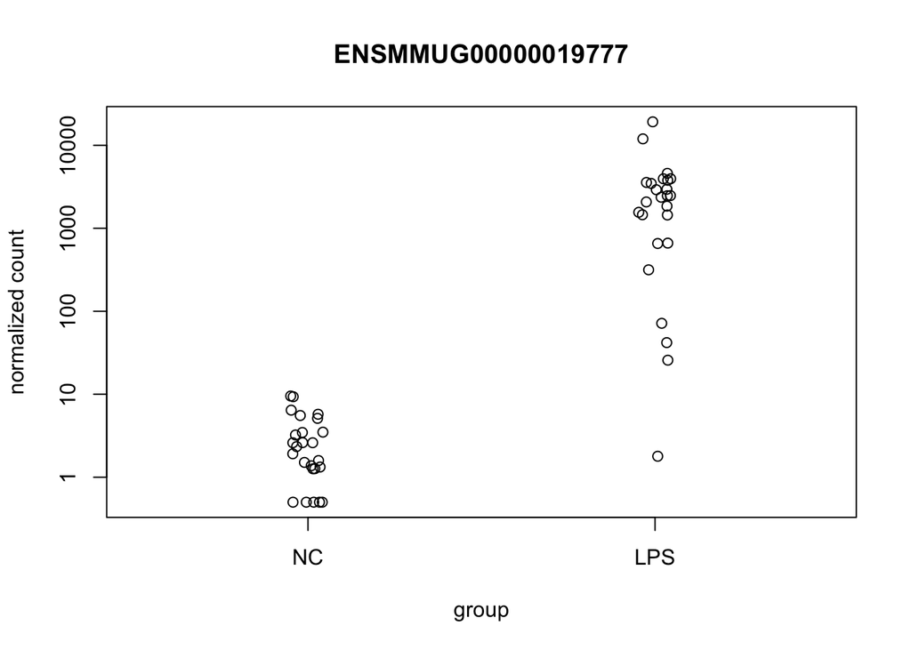

```r
plotCounts(dds, gene=which.min(result$padj), intgroup="condition")
```

### Exporting results

Writing a result file:

```r
write.csv(as.data.frame(resultOrdered), file="DESeq2_DEgenes_condition_LPS_NC.csv")
```

## edgeR

Let’s do the same but using `edgeR` package. Please load the `edgeR` library.

```r
library("edgeR")
```

Make an object with the read count and sample information and look at it. You will see how samples got assigned to groups (LPS or NC), what the library sizes are, the counts for each gene etc.

```r
count_edgeR_obj=DGEList(counts=readcounts, group=coldata$condition)
count_edgeR_obj
```

```
## An object of class "DGEList"
## $counts
##                    SRR3660629 SRR3660630 SRR3660632 SRR3660633 SRR3660636
## ENSMMUG00000005947          0          0          1          4          1
## ENSMMUG00000015800        643        574        284        498        404
## ENSMMUG00000015802        185        215        135        188        107
## ENSMMUG00000015804         33         25         21         50         72
## ENSMMUG00000022525         15         10         17          9         26
##                    SRR3660637 SRR3660640 SRR3660641 SRR3660642 SRR3660643
## ENSMMUG00000005947          2          6          4          3          1
## ENSMMUG00000015800        559        371        332        336        449
## ENSMMUG00000015802        108        119         62         67         76
## ENSMMUG00000015804         78         34         23         17         12
## ENSMMUG00000022525         32         10          7         17          5
##                    SRR3660644 SRR3660645 SRR3660646 SRR3660649 SRR3660650
## ENSMMUG00000005947          1          0          0          9          9
## ENSMMUG00000015800        284        668        548        702        830
## ENSMMUG00000015802         47        133        173        166        131
## ENSMMUG00000015804         19         18         48         28         58
## ENSMMUG00000022525          7          1         32         21         25
##                    SRR3660651 SRR3660652 SRR3660654 SRR3660655 SRR3660659
## ENSMMUG00000005947          3          2          0          1          0
## ENSMMUG00000015800        378        478        664        642        294
## ENSMMUG00000015802        125        151         90        101         70
## ENSMMUG00000015804         30         47         41         33         21
## ENSMMUG00000022525         16         29         14         12          9
##                    SRR3660660 SRR3660661 SRR3660665 SRR3660666 SRR3660668
## ENSMMUG00000005947          1          2          7          8          0
## ENSMMUG00000015800        582        343        306        304        206
## ENSMMUG00000015802        130        109         91         72         51
## ENSMMUG00000015804         26         27         17         18         15
## ENSMMUG00000022525         14          0         11         14          5
##                    SRR3660669 SRR3660670 SRR3660671 SRR3660672 SRR3660673
## ENSMMUG00000005947          0          1          1          1          4
## ENSMMUG00000015800        335        401        366        138        474
## ENSMMUG00000015802         86         49         72         33        115
## ENSMMUG00000015804         15         16         11          8         20
## ENSMMUG00000022525         18         14          1          2          5
##                    SRR3660676 SRR3660677 SRR3660678 SRR3660679 SRR3660686
## ENSMMUG00000005947          0          6          2          2          4
```

[output cut: 17 more lines]

```
## ENSMMUG00000005947          4          8          9          2          5
## ENSMMUG00000015800        250        657        647        788        763
## ENSMMUG00000015802         54        172        170        248        156
## ENSMMUG00000015804          9         27         40         64         49
## ENSMMUG00000022525          1         19         17         24         24
## 32381 more rows ...
##
## $samples
##            group lib.size norm.factors
## SRR3660629   LPS 13066106            1
## SRR3660630    NC 12697985            1
## SRR3660632   LPS  9188200            1
## SRR3660633    NC 11947563            1
## SRR3660636   LPS  9331709            1
## 45 more rows ...
```

### Normalization

`edgeR` uses the quantile-adjusted conditional maximum likelihood (qCML) method to estimate the dispersion(s) before comparing two groups of samples. It first determines the common dispersion and then the dispersion for each gene. For the gene-wise dispersion, it implements an empirical Bayes strategy for squeezing the gene-wise dispersions towards the common dispersion.  
Takes a few seconds.

```r
count_edgeR_obj=estimateCommonDisp(count_edgeR_obj)
count_edgeR_obj=estimateTagwiseDisp(count_edgeR_obj)
```

### Calculating differential expression

`edgR` uses something similar to a Fisher’s exact test and is based on the qCML method. Per default it will adjust the p-values with the Benjamini-Hochberg method.  
Takes a few seconds.  
Then look at the resulting object.

```r
edgeR_DEgenes=exactTest(count_edgeR_obj)
edgeR_DEgenes
```

```
## An object of class "DGEExact"
## $table
##                          logFC     logCPM    PValue
## ENSMMUG00000005947 -0.12042125 -1.0568964 0.8294583
## ENSMMUG00000015800  0.09687025  5.4714219 0.5639310
## ENSMMUG00000015802  0.04940899  3.4127237 0.8113648
## ENSMMUG00000015804 -0.12161692  1.4585644 0.6176807
## ENSMMUG00000022525 -0.47718363  0.5230822 0.1398833
## 32381 more rows ...
##
## $comparison
## [1] "LPS" "NC"
##
## $genes
## NULL
```

The function `topTags()` is used to show the top differentially expressed genes (default: based on p-value).

```r
topTags(edgeR_DEgenes)
```

```
## Comparison of groups:  NC-LPS
##                         logFC    logCPM       PValue          FDR
## ENSMMUG00000019777 -10.008028  7.137702 6.041468e-52 1.956590e-47
## ENSMMUG00000020374  -4.149292 10.542604 6.447180e-47 1.043992e-42
## ENSMMUG00000013250  -9.259378  6.538996 6.595210e-42 7.119749e-38
## ENSMMUG00000014072  -4.691763  6.303535 1.402129e-41 1.135234e-37
## ENSMMUG00000013014  -5.778537  8.704701 1.126761e-35 7.298257e-32
## ENSMMUG00000020102  -4.454308  7.556316 1.696654e-35 9.157973e-32
## ENSMMUG00000042751  -5.523590 10.642894 2.364211e-34 1.093819e-30
## ENSMMUG00000004930  -3.432016  7.510842 1.113371e-32 4.507204e-29
## ENSMMUG00000016671  -6.438514  9.403349 3.283289e-32 1.181473e-28
## ENSMMUG00000039336  -8.246857  6.120395 1.178060e-31 3.815265e-28
```

To show the top differentially expressed genes based on fold change use:

```r
topTags(edgeR_DEgenes, sort.by = "logFC")
```

```
## Comparison of groups:  NC-LPS
##                         logFC   logCPM       PValue          FDR
## ENSMMUG00000019777 -10.008028 7.137702 6.041468e-52 1.956590e-47
## ENSMMUG00000013250  -9.259378 6.538996 6.595210e-42 7.119749e-38
## ENSMMUG00000039336  -8.246857 6.120395 1.178060e-31 3.815265e-28
## ENSMMUG00000019983  -8.108459 6.099163 2.202399e-24 3.101169e-21
## ENSMMUG00000048596  -7.501560 5.436675 5.372517e-26 9.666352e-23
## ENSMMUG00000021701  -7.287543 5.437039 1.071694e-20 1.020820e-17
## ENSMMUG00000016925  -7.050065 5.855098 1.522986e-23 1.700808e-20
## ENSMMUG00000008434  -6.622222 2.869479 7.455200e-14 2.775220e-11
## ENSMMUG00000016671  -6.438514 9.403349 3.283289e-32 1.181473e-28
## ENSMMUG00000008367  -6.358815 5.934822 8.441123e-26 1.438812e-22
```

As seen above, the `edgeR_DEgenes` object contains multiple elements. The first one is the table with `logFC`, `logCPM`, and `p-values` for each gene. To get access to this table and assign it to a new variable, call:

```r
edgeR_DEgenesTable=edgeR_DEgenes$table
head(edgeR_DEgenesTable)
```

|  | logFC | logCPM | PValue |
| --- | --- | --- | --- |
| ENSMMUG00000005947 | -0.12042125 | -1.0568964 | 0.829458322 |
| ENSMMUG00000015800 | 0.09687025 | 5.4714219 | 0.563931015 |
| ENSMMUG00000015802 | 0.04940899 | 3.4127237 | 0.811364829 |
| ENSMMUG00000015804 | -0.12161692 | 1.4585644 | 0.617680701 |
| ENSMMUG00000022525 | -0.47718363 | 0.5230822 | 0.139883335 |
| ENSMMUG00000008350 | -1.82031341 | -1.9705641 | 0.004600541 |

Now you can extract significant genes.

```r
signedgeR_DEgenes=edgeR_DEgenesTable[edgeR_DEgenesTable[,3]<0.05,]
```

Write a result file with genes sorted by p-value.

```r
edgeROrdered <- edgeR_DEgenesTable[order(edgeR_DEgenesTable$PValue),]
write.csv(as.data.frame(edgeR_DEgenesTable), file="edgeR_DEgenes_condition_LPS_NC.csv")
```

## Exercise 1

1.1. Which method calls more significant genes, `DESeq2` or `edgeR`?

1.2. How many genes were called differentially expressed with both methods? Hint1: check out `%in%` Hint2: are p-values adjusted for both methods?

1.3. A venn diagram is also a good way to visualize overlap. Check out the `eulerr` package (Note, this package is not included for pre-installation before the tutorial, so work with your neighbor who has faster machine to install this package).

# Differential expression analysis with multi-factor designs (DEseq2)

Experiments with more than one factor influencing the counts can be analyzed using design formula that include the additional variables. In fact, `DESeq2` can analyze any possible experimental design that can be expressed with fixed effects terms (multiple factors, designs with interactions, designs with continuous variables, splines, and so on are all possible).

Look with `colData()` at your `DESeq2` object to see the different factors of the experimental design. Individuals belong to different study groups (the groups are like experimental replicates). Within each group, individuals are of different ranks.  
With `unique()` you can then ask for a list of all study groups or ranks, respectively.

```r
colData(dds)
```

```
## DataFrame with 50 rows and 6 columns
##             subject_id condition study_group      rank sizeFactor replaceable
##            <character>  <factor> <character> <integer>  <numeric>   <logical>
## SRR3660629        RAc8       LPS    VBB_SGE2         4   1.619082        TRUE
## SRR3660630        RAc8       NC     VBB_SGE2         4   1.689615        TRUE
## SRR3660632       RCw10       LPS   Cw10_SGE2         1   0.891046        TRUE
## SRR3660633       RCw10       NC    Cw10_SGE2         1   1.180836        TRUE
## SRR3660636       REg12       LPS    Fq9_SGE2         3   0.890802        TRUE
## ...                ...       ...         ...       ...        ...         ...
## SRR3660700       RVw12       NC     Fq9_SGE2         4   0.792848        TRUE
## SRR3660701       RWu12       LPS   Pp10_SGE2         4   0.912051        TRUE
## SRR3660702       RWu12       NC    Pp10_SGE2         4   0.992688        TRUE
## SRR3660707         VBB       LPS    VBB_SGE2         1   1.338809        TRUE
## SRR3660708         VBB       NC     VBB_SGE2         1   1.310931        TRUE
```

```r
unique(colData(dds)$study_group)
```

```
## [1] "VBB_SGE2"  "Cw10_SGE2" "Fq9_SGE2"  "Pp10_SGE2" "Jl11_SGE2"
```

```r
unique(colData(dds)$rank)
```

```
## [1] 4 1 3 2 5
```

In contrast to what we did before, we now want to take the ranks of the individuals into account for comparing treatment vs. control. Therefore, ranks needs to be converted to factors:

```r
coldata$rank = as.factor(coldata$rank)
```

We make a new `DESeqDataSet` object. It will hold the count information for each gene for each sample.

```r
dds_interact=DESeqDataSetFromMatrix(countData = readcounts,
                                    colData = coldata,
                                    design = ~ condition + rank + condition:rank)
dds_interact
```

```
## class: DESeqDataSet
## dim: 32386 50
## metadata(1): version
## assays(1): counts
## rownames(32386): ENSMMUG00000005947 ENSMMUG00000015800 ...
##   ENSMMUG00000042591 ENSMMUG00000026105
## rowData names(0):
## colnames(50): SRR3660629 SRR3660630 ... SRR3660707 SRR3660708
## colData names(4): subject_id condition study_group rank
```

### Pre-filtering

We again filter out genes with very low expression to reduce noise, removing all genes with lower than 10 reads in total across all samples.

```r
keep = rowSums(counts(dds_interact)) >= 10
dds_interact = dds_interact[keep,]
dds_interact
```

```
## class: DESeqDataSet
## dim: 21391 50
## metadata(1): version
## assays(1): counts
## rownames(21391): ENSMMUG00000005947 ENSMMUG00000015800 ...
##   ENSMMUG00000048985 ENSMMUG00000049032
## rowData names(0):
## colnames(50): SRR3660629 SRR3660630 ... SRR3660707 SRR3660708
## colData names(4): subject_id condition study_group rank
```

### Note on factor levels

Now we can specify the factors for the comparisons. Here we will consider the condition and the ranks.

```r
dds_interact$condition = factor(dds_interact$condition, levels = c("NC","LPS"))
dds_interact$rank = factor(dds_interact$rank, levels = c("1","2","3","4","5"))
```

### Differential expression analysis

This will now take a bit longer than before (ca. 5 minutes).

```r
dds_interact = DESeq(dds_interact)
results(dds_interact)
```

```
## log2 fold change (MLE): conditionLPS.rank5
## Wald test p-value: conditionLPS.rank5
## DataFrame with 21391 rows and 6 columns
##                     baseMean log2FoldChange     lfcSE       stat    pvalue
##                    <numeric>      <numeric> <numeric>  <numeric> <numeric>
## ENSMMUG00000005947   3.23429       0.879033  1.695730   0.518380  0.604193
## ENSMMUG00000015800 452.51457       0.139061  0.396812   0.350445  0.726004
## ENSMMUG00000015802 106.99731      -0.168852  0.538711  -0.313437  0.753949
## ENSMMUG00000015804  26.82127       0.667950  0.693659   0.962937  0.335579
## ENSMMUG00000022525  13.33049      -0.199437  1.046693  -0.190540  0.848886
## ...                      ...            ...       ...        ...       ...
## ENSMMUG00000041270  0.485931     -0.7800178   2.90001 -0.2689706  0.787952
## ENSMMUG00000043278  0.628620     -1.7888318   2.83545 -0.6308805  0.528119
## ENSMMUG00000036864  1.005056     -0.0271355   2.29675 -0.0118147  0.990573
## ENSMMUG00000048985  0.234933      2.8100269   9.27982  0.3028104  0.762034
## ENSMMUG00000049032  0.323819      1.4331035   6.71190  0.2135168  0.830924
##                         padj
##                    <numeric>
## ENSMMUG00000005947  0.999911
## ENSMMUG00000015800  0.999911
## ENSMMUG00000015802  0.999911
## ENSMMUG00000015804  0.999911
## ENSMMUG00000022525  0.999911
## ...                      ...
## ENSMMUG00000041270  0.999911
## ENSMMUG00000043278  0.999911
## ENSMMUG00000036864  0.999911
## ENSMMUG00000048985  0.999911
## ENSMMUG00000049032  0.999911
```

To show the comparisons that were done use the function `resultNames()` on the `DESeq` object.

```r
resultsNames(dds_interact)
```

```
##  [1] "Intercept"           "condition_LPS_vs_NC" "rank_2_vs_1"
##  [4] "rank_3_vs_1"         "rank_4_vs_1"         "rank_5_vs_1"
##  [7] "conditionLPS.rank2"  "conditionLPS.rank3"  "conditionLPS.rank4"
## [10] "conditionLPS.rank5"
```

### Exercise 2

Perform the following five comparisons. To do so, check the help for `?results`. Hint: Most important are to see what the contrast argument wants and the examples at the bottom of the help pages.

2.1. The main effect (treatment vs. control) for first group (Rank 1).

2.2. Rank 1 vs. Rank 5.

2.3. The condition effect for Rank 2 (takes a few seconds). This is the main effect plus the interaction term.

2.4. Interaction term for condition effect in Rank 2 vs. Rank 5 to find out whether the condition effect is different between these two ranks.

2.5. How many genes differ in their change between treatment vs. control between Rank 2 and Rank 5? Hint: To summarize the results and see what the columns in the results object mean, you need to assign the output of results to a variable.

# Network analysis

## Building weighted topological overlap (wTO) networks

`wTO` package uses a method computing the Weighted Topological Overlap with positive and negative signs (wTO) networks given a data frame containing the **mRNA count/ expression/ abundance per sample**, and a vector containing the **interested nodes** of interaction (a subset of the elements of the full data frame). Simply said, we will make a transcription factor (TF = interested nodes) wTO network for control samples (NC = expression) and one for the treatment samples (LPS = expression) separately. We will only consider differentially expressed genes, which will help to reduce run time.

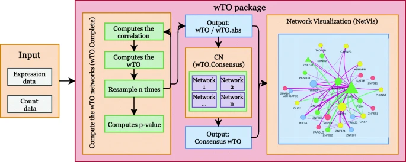

The wTO package workflow

Now, let’s load the `wTO` package.

```r
require(wTO)
require(magrittr)
```

### Splitting the input file into one for control (NC) and one for treatment (LPS)

First, collecting all NC samples:

```r
NC = readcounts[,coldata$condition == 'NC']
dim(NC)
```

```
## [1] 32386    25
```

Removing genes that have less than 10 counts:

```r
NC = NC[rowSums(NC)> 10,]
dim(NC)
```

```
## [1] 19759    25
```

Then, collecting all LPS samples and removing genes that have less than 10 counts:

```r
LPS = readcounts[,coldata$condition == 'LPS']
dim(LPS)
```

```
## [1] 32386    25
```

```r
LPS = LPS[rowSums(LPS)> 10,]
dim(LPS)
```

```
## [1] 19744    25
```

We can now select only the significant genes from the tables with LPS and NC samples. But before, we will have a look at the results from before again:

```r
summary(result)
```

```
##
## out of 21389 with nonzero total read count
## adjusted p-value < 0.1
## LFC > 0 (up)       : 1125, 5.3%
## LFC < 0 (down)     : 482, 2.3%
## outliers [1]       : 0, 0%
## low counts [2]     : 2490, 12%
## (mean count < 1)
## [1] see 'cooksCutoff' argument of ?results
## [2] see 'independentFiltering' argument of ?results
```

```r
DE_genes = subset(row.names(result), result$padj<0.01)
NC = subset(NC, row.names(NC) %in% DE_genes)
LPS = subset(LPS, row.names(LPS) %in% DE_genes)
```

We want to make a TF wTO network. Thus, we need to retrieve the information about TF genes. The list of TFs is in the file `TFs.txt`. Let’s read this file into our R session.

```r
TFs = read.table("files/TFs.txt", header=TRUE, sep="\t", stringsAsFactors=FALSE)
dim(TFs)
```

```
## [1] 1834    1
```

```r
TFs = TFs[,1]
length(TFs)[[1]]
```

```
## [1] 1834
```

We obtained 1834 TFs. However, their IDs are `GeneSymbols`, while our table with readcounts used Ensembl gene IDs. So, we cannot easily match these IDs to identify the TFs in our LPS and NC tables.  
We will thus take a short digression into `Biomart`, with which we can annotate our genes. Here, we want to change all Ensembl gene IDs in the LPS and NC tables to `GeneSymbols`. This way, we can match them with the TF table and our resulting network will display the TF `GeneSymbols` at the nodes.

### Gene annotation

Load the R package `biomaRt`.

```r
library(biomaRt)
```

We first have to choose a `Mart` and a `Dataset`.  
The function `listMarts()` shows all available Marts. We need ensembl.

```r
listMarts()
```

| biomart | version |
| --- | --- |
| ENSEMBL_MART_ENSEMBL | Ensembl Genes 109 |
| ENSEMBL_MART_MOUSE | Mouse strains 109 |
| ENSEMBL_MART_SNP | Ensembl Variation 109 |
| ENSEMBL_MART_FUNCGEN | Ensembl Regulation 109 |

```r
ensembl=useMart("ensembl")
```

We also need to select the right species. `listDatasets()` will show all available species. Because that list is very long, it is not printed in tis tutorial. We need to pick the dataset for rhesus macaque (`mmulatta_gene_ensembl`).  
Then we can build our `Mart` with the function `useDataset()`.

```r
listDatasets(ensembl)
mart = useDataset("mmulatta_gene_ensembl", useMart("ensembl"))
```

We want to convert the Ensembl Gene IDs of all expressed genes into `GeneSymbols` (`external_gene_name`).  
The list of all expressed genes is contained in the row names of the result object.  
The information we can retrieve is stored in `Biomart` as attributes. The function `listAttributes()` prints all available attributes. This long list of attributes is not printed in this tutorial. Have a look at what information you could retrieve. We need to pick the `external_gene_name`.

```r
expressedGenes=row.names(result)
listAttributes(mart)
```

Now we can use `getBM()` with the right filters, attributes, and values. Our filters are to take only genes with an `ensembl_gene_id`. Our attributes say that we want to retrieve the `ensembl_gene_id` and the `external_gene_name`. Values specifies that we only want this information for the expressed genes.  
This takes about one minute.

```r
GeneSymbols = getBM(filters= "ensembl_gene_id", attributes= c("ensembl_gene_id", 'external_gene_name'),values=expressedGenes,mart= mart)
dim(GeneSymbols)
```

```
## [1] 15371     2
```

```r
head (GeneSymbols)
```

|  | ensembl_gene_id | external_gene_name |
| --- | --- | --- |
| 1 | ENSMMUG00000000009 | PTPRC |
| 2 | ENSMMUG00000000015 | C1H1orf100 |
| 3 | ENSMMUG00000000016 | ADSS2 |
| 4 | ENSMMUG00000000021 | CATSPERE |
| 5 | ENSMMUG00000000037 | ISG20L2 |
| 6 | ENSMMUG00000000038 | METTL25B |

The table `GeneSymbols` has two columns, with which we can now match or substitute `ensembl_gene_id` by `GeneSymbols` in the LPS and NC tables.  
Note, some genes do not have a Gene symbol but an “NA” instead. Also, some genes are duplicated (representing different isoforms). We are now reformating our LPS and NC tables such that they will contain `GeneSymbols`. We will use the package `plyr` for that.

```r
require(plyr)
```

```r
LPS$ensembl_gene_id = row.names(LPS)
LPS = join(LPS, GeneSymbols, type = 'inner', match = 'first')
head(LPS)
```

|  | ensembl_gene_id | SRR3660629 | SRR3660632 | SRR3660636 | SRR3660640 | SRR3660642 | SRR3660644 | SRR3660646 | SRR3660649 | SRR3660651 | SRR3660654 | SRR3660660 | SRR3660665 | SRR3660668 | SRR3660670 | SRR3660672 | SRR3660676 | SRR3660678 | SRR3660686 | SRR3660691 | SRR3660693 | SRR3660695 | SRR3660697 | SRR3660699 | SRR3660701 | SRR3660707 | external_gene_name |
| --- | --- | --- | --- | --- | --- | --- | --- | --- | --- | --- | --- | --- | --- | --- | --- | --- | --- | --- | --- | --- | --- | --- | --- | --- | --- | --- | --- |
| ENSMMUG00000000406 | ENSMMUG00000000406 | 0 | 0 | 0 | 1 | 2 | 1 | 0 | 6 | 0 | 2 | 0 | 0 | 3 | 0 | 0 | 1 | 2 | 1 | 3 | 0 | 1 | 0 | 1 | 0 | 0 | HES4 |
| ENSMMUG00000000662 | ENSMMUG00000000662 | 6316 | 2981 | 7307 | 6622 | 2215 | 1486 | 4071 | 228 | 7098 | 7434 | 6047 | 2426 | 1221 | 21995 | 1476 | 1097 | 2375 | 1369 | 5358 | 1276 | 2247 | 1495 | 2822 | 196 | 1244 | TNFRSF14 |
| ENSMMUG00000000984 | ENSMMUG00000000984 | 44 | 16 | 102 | 50 | 32 | 98 | 4 | 7 | 27 | 78 | 162 | 56 | 7 | 257 | 168 | 5 | 50 | 81 | 374 | 18 | 72 | 94 | 167 | 13 | 19 | PRXL2B |
| ENSMMUG00000001096 | ENSMMUG00000001096 | 166 | 60 | 57 | 88 | 54 | 44 | 77 | 127 | 32 | 98 | 96 | 50 | 54 | 57 | 40 | 73 | 123 | 33 | 74 | 45 | 104 | 69 | 56 | 77 | 108 | MMEL1 |
| ENSMMUG00000001300 | ENSMMUG00000001300 | 729 | 12 | 13 | 5 | 22 | 100 | 13 | 5 | 20 | 85 | 283 | 15 | 19 | 138 | 108 | 15 | 53 | 117 | 197 | 10 | 88 | 12 | 22 | 1 | 36 | FBXO6 |
| ENSMMUG00000001443 | ENSMMUG00000001443 | 8108 | 1413 | 2375 | 2733 | 3192 | 3239 | 754 | 1079 | 1307 | 6246 | 3668 | 1052 | 907 | 8137 | 3518 | 1065 | 3466 | 2879 | 4591 | 579 | 3553 | 2190 | 3231 | 758 | 1348 | TNFRSF8 |

Removing duplicates:

```r
LPS = LPS[!duplicated(LPS$external_gene_name), ]
row.names(LPS) = LPS$external_gene_name
head(LPS)
```

|  | ensembl_gene_id | SRR3660629 | SRR3660632 | SRR3660636 | SRR3660640 | SRR3660642 | SRR3660644 | SRR3660646 | SRR3660649 | SRR3660651 | SRR3660654 | SRR3660660 | SRR3660665 | SRR3660668 | SRR3660670 | SRR3660672 | SRR3660676 | SRR3660678 | SRR3660686 | SRR3660691 | SRR3660693 | SRR3660695 | SRR3660697 | SRR3660699 | SRR3660701 | SRR3660707 | external_gene_name |
| --- | --- | --- | --- | --- | --- | --- | --- | --- | --- | --- | --- | --- | --- | --- | --- | --- | --- | --- | --- | --- | --- | --- | --- | --- | --- | --- | --- |
| HES4 | ENSMMUG00000000406 | 0 | 0 | 0 | 1 | 2 | 1 | 0 | 6 | 0 | 2 | 0 | 0 | 3 | 0 | 0 | 1 | 2 | 1 | 3 | 0 | 1 | 0 | 1 | 0 | 0 | HES4 |
| TNFRSF14 | ENSMMUG00000000662 | 6316 | 2981 | 7307 | 6622 | 2215 | 1486 | 4071 | 228 | 7098 | 7434 | 6047 | 2426 | 1221 | 21995 | 1476 | 1097 | 2375 | 1369 | 5358 | 1276 | 2247 | 1495 | 2822 | 196 | 1244 | TNFRSF14 |
| PRXL2B | ENSMMUG00000000984 | 44 | 16 | 102 | 50 | 32 | 98 | 4 | 7 | 27 | 78 | 162 | 56 | 7 | 257 | 168 | 5 | 50 | 81 | 374 | 18 | 72 | 94 | 167 | 13 | 19 | PRXL2B |
| MMEL1 | ENSMMUG00000001096 | 166 | 60 | 57 | 88 | 54 | 44 | 77 | 127 | 32 | 98 | 96 | 50 | 54 | 57 | 40 | 73 | 123 | 33 | 74 | 45 | 104 | 69 | 56 | 77 | 108 | MMEL1 |
| FBXO6 | ENSMMUG00000001300 | 729 | 12 | 13 | 5 | 22 | 100 | 13 | 5 | 20 | 85 | 283 | 15 | 19 | 138 | 108 | 15 | 53 | 117 | 197 | 10 | 88 | 12 | 22 | 1 | 36 | FBXO6 |
| TNFRSF8 | ENSMMUG00000001443 | 8108 | 1413 | 2375 | 2733 | 3192 | 3239 | 754 | 1079 | 1307 | 6246 | 3668 | 1052 | 907 | 8137 | 3518 | 1065 | 3466 | 2879 | 4591 | 579 | 3553 | 2190 | 3231 | 758 | 1348 | TNFRSF8 |

```r
ncol(LPS)
```

```
## [1] 27
```

```r
names(LPS)
```

```
##  [1] "ensembl_gene_id"    "SRR3660629"         "SRR3660632"
##  [4] "SRR3660636"         "SRR3660640"         "SRR3660642"
##  [7] "SRR3660644"         "SRR3660646"         "SRR3660649"
## [10] "SRR3660651"         "SRR3660654"         "SRR3660660"
## [13] "SRR3660665"         "SRR3660668"         "SRR3660670"
## [16] "SRR3660672"         "SRR3660676"         "SRR3660678"
## [19] "SRR3660686"         "SRR3660691"         "SRR3660693"
## [22] "SRR3660695"         "SRR3660697"         "SRR3660699"
## [25] "SRR3660701"         "SRR3660707"         "external_gene_name"
```

Removing first column with Ensembl IDs and last column with GeneSymbols:

```r
LPS = LPS[, -c(1,27)]
head(LPS)
```

|  | SRR3660629 | SRR3660632 | SRR3660636 | SRR3660640 | SRR3660642 | SRR3660644 | SRR3660646 | SRR3660649 | SRR3660651 | SRR3660654 | SRR3660660 | SRR3660665 | SRR3660668 | SRR3660670 | SRR3660672 | SRR3660676 | SRR3660678 | SRR3660686 | SRR3660691 | SRR3660693 | SRR3660695 | SRR3660697 | SRR3660699 | SRR3660701 | SRR3660707 |
| --- | --- | --- | --- | --- | --- | --- | --- | --- | --- | --- | --- | --- | --- | --- | --- | --- | --- | --- | --- | --- | --- | --- | --- | --- | --- |
| HES4 | 0 | 0 | 0 | 1 | 2 | 1 | 0 | 6 | 0 | 2 | 0 | 0 | 3 | 0 | 0 | 1 | 2 | 1 | 3 | 0 | 1 | 0 | 1 | 0 | 0 |
| TNFRSF14 | 6316 | 2981 | 7307 | 6622 | 2215 | 1486 | 4071 | 228 | 7098 | 7434 | 6047 | 2426 | 1221 | 21995 | 1476 | 1097 | 2375 | 1369 | 5358 | 1276 | 2247 | 1495 | 2822 | 196 | 1244 |
| PRXL2B | 44 | 16 | 102 | 50 | 32 | 98 | 4 | 7 | 27 | 78 | 162 | 56 | 7 | 257 | 168 | 5 | 50 | 81 | 374 | 18 | 72 | 94 | 167 | 13 | 19 |
| MMEL1 | 166 | 60 | 57 | 88 | 54 | 44 | 77 | 127 | 32 | 98 | 96 | 50 | 54 | 57 | 40 | 73 | 123 | 33 | 74 | 45 | 104 | 69 | 56 | 77 | 108 |
| FBXO6 | 729 | 12 | 13 | 5 | 22 | 100 | 13 | 5 | 20 | 85 | 283 | 15 | 19 | 138 | 108 | 15 | 53 | 117 | 197 | 10 | 88 | 12 | 22 | 1 | 36 |
| TNFRSF8 | 8108 | 1413 | 2375 | 2733 | 3192 | 3239 | 754 | 1079 | 1307 | 6246 | 3668 | 1052 | 907 | 8137 | 3518 | 1065 | 3466 | 2879 | 4591 | 579 | 3553 | 2190 | 3231 | 758 | 1348 |

```r
dim(LPS)
```

```
## [1] 690  25
```

Performing the same annotation and reformating for the NC table:

```r
NC$ensembl_gene_id = row.names(NC)
NC = join(NC, GeneSymbols, type = 'inner', match = 'first')
head(NC)
```

|  | ensembl_gene_id | SRR3660630 | SRR3660633 | SRR3660637 | SRR3660641 | SRR3660643 | SRR3660645 | SRR3660650 | SRR3660652 | SRR3660655 | SRR3660659 | SRR3660661 | SRR3660666 | SRR3660669 | SRR3660671 | SRR3660673 | SRR3660677 | SRR3660679 | SRR3660687 | SRR3660692 | SRR3660694 | SRR3660696 | SRR3660698 | SRR3660700 | SRR3660702 | SRR3660708 | external_gene_name |
| --- | --- | --- | --- | --- | --- | --- | --- | --- | --- | --- | --- | --- | --- | --- | --- | --- | --- | --- | --- | --- | --- | --- | --- | --- | --- | --- | --- |
| ENSMMUG00000000406 | ENSMMUG00000000406 | 17 | 0 | 7 | 7 | 8 | 14 | 12 | 2 | 0 | 0 | 2 | 1 | 2 | 3 | 5 | 2 | 5 | 10 | 21 | 0 | 7 | 0 | 3 | 2 | 1 | HES4 |
| ENSMMUG00000000662 | ENSMMUG00000000662 | 7605 | 422 | 1343 | 1112 | 571 | 772 | 264 | 1930 | 509 | 3622 | 261 | 515 | 1338 | 1106 | 526 | 354 | 1120 | 372 | 1702 | 2003 | 522 | 246 | 731 | 206 | 366 | TNFRSF14 |
| ENSMMUG00000000984 | ENSMMUG00000000984 | 6 | 3 | 1 | 2 | 3 | 0 | 12 | 6 | 3 | 2 | 2 | 23 | 5 | 3 | 2 | 5 | 5 | 10 | 1 | 4 | 9 | 29 | 7 | 20 | 13 | PRXL2B |
| ENSMMUG00000001096 | ENSMMUG00000001096 | 177 | 108 | 73 | 115 | 94 | 171 | 121 | 105 | 120 | 52 | 90 | 146 | 35 | 149 | 147 | 84 | 154 | 77 | 215 | 52 | 196 | 81 | 110 | 113 | 84 | MMEL1 |
| ENSMMUG00000001300 | ENSMMUG00000001300 | 5 | 12 | 2 | 2 | 3 | 11 | 9 | 2 | 9 | 12 | 13 | 6 | 17 | 10 | 7 | 5 | 4 | 2 | 10 | 11 | 9 | 0 | 1 | 5 | 17 | FBXO6 |
| ENSMMUG00000001443 | ENSMMUG00000001443 | 3886 | 1345 | 1449 | 2120 | 2627 | 4797 | 1425 | 1380 | 3458 | 974 | 1042 | 1175 | 394 | 3851 | 2352 | 641 | 2154 | 2060 | 4436 | 1354 | 2982 | 1082 | 1547 | 795 | 1226 | TNFRSF8 |

```r
NC = NC[!duplicated(NC$external_gene_name), ]
row.names(NC) = NC$external_gene_name
head(NC)
```

|  | ensembl_gene_id | SRR3660630 | SRR3660633 | SRR3660637 | SRR3660641 | SRR3660643 | SRR3660645 | SRR3660650 | SRR3660652 | SRR3660655 | SRR3660659 | SRR3660661 | SRR3660666 | SRR3660669 | SRR3660671 | SRR3660673 | SRR3660677 | SRR3660679 | SRR3660687 | SRR3660692 | SRR3660694 | SRR3660696 | SRR3660698 | SRR3660700 | SRR3660702 | SRR3660708 | external_gene_name |
| --- | --- | --- | --- | --- | --- | --- | --- | --- | --- | --- | --- | --- | --- | --- | --- | --- | --- | --- | --- | --- | --- | --- | --- | --- | --- | --- | --- |
| HES4 | ENSMMUG00000000406 | 17 | 0 | 7 | 7 | 8 | 14 | 12 | 2 | 0 | 0 | 2 | 1 | 2 | 3 | 5 | 2 | 5 | 10 | 21 | 0 | 7 | 0 | 3 | 2 | 1 | HES4 |
| TNFRSF14 | ENSMMUG00000000662 | 7605 | 422 | 1343 | 1112 | 571 | 772 | 264 | 1930 | 509 | 3622 | 261 | 515 | 1338 | 1106 | 526 | 354 | 1120 | 372 | 1702 | 2003 | 522 | 246 | 731 | 206 | 366 | TNFRSF14 |
| PRXL2B | ENSMMUG00000000984 | 6 | 3 | 1 | 2 | 3 | 0 | 12 | 6 | 3 | 2 | 2 | 23 | 5 | 3 | 2 | 5 | 5 | 10 | 1 | 4 | 9 | 29 | 7 | 20 | 13 | PRXL2B |
| MMEL1 | ENSMMUG00000001096 | 177 | 108 | 73 | 115 | 94 | 171 | 121 | 105 | 120 | 52 | 90 | 146 | 35 | 149 | 147 | 84 | 154 | 77 | 215 | 52 | 196 | 81 | 110 | 113 | 84 | MMEL1 |
| FBXO6 | ENSMMUG00000001300 | 5 | 12 | 2 | 2 | 3 | 11 | 9 | 2 | 9 | 12 | 13 | 6 | 17 | 10 | 7 | 5 | 4 | 2 | 10 | 11 | 9 | 0 | 1 | 5 | 17 | FBXO6 |
| TNFRSF8 | ENSMMUG00000001443 | 3886 | 1345 | 1449 | 2120 | 2627 | 4797 | 1425 | 1380 | 3458 | 974 | 1042 | 1175 | 394 | 3851 | 2352 | 641 | 2154 | 2060 | 4436 | 1354 | 2982 | 1082 | 1547 | 795 | 1226 | TNFRSF8 |

```r
ncol(NC)
```

```
## [1] 27
```

```r
dim(NC)
```

```
## [1] 681  27
```

```r
names(NC)
```

```
##  [1] "ensembl_gene_id"    "SRR3660630"         "SRR3660633"
##  [4] "SRR3660637"         "SRR3660641"         "SRR3660643"
##  [7] "SRR3660645"         "SRR3660650"         "SRR3660652"
## [10] "SRR3660655"         "SRR3660659"         "SRR3660661"
## [13] "SRR3660666"         "SRR3660669"         "SRR3660671"
## [16] "SRR3660673"         "SRR3660677"         "SRR3660679"
## [19] "SRR3660687"         "SRR3660692"         "SRR3660694"
## [22] "SRR3660696"         "SRR3660698"         "SRR3660700"
## [25] "SRR3660702"         "SRR3660708"         "external_gene_name"
```

```r
NC = NC[, -c(1,27)]
head(NC)
```

|  | SRR3660630 | SRR3660633 | SRR3660637 | SRR3660641 | SRR3660643 | SRR3660645 | SRR3660650 | SRR3660652 | SRR3660655 | SRR3660659 | SRR3660661 | SRR3660666 | SRR3660669 | SRR3660671 | SRR3660673 | SRR3660677 | SRR3660679 | SRR3660687 | SRR3660692 | SRR3660694 | SRR3660696 | SRR3660698 | SRR3660700 | SRR3660702 | SRR3660708 |
| --- | --- | --- | --- | --- | --- | --- | --- | --- | --- | --- | --- | --- | --- | --- | --- | --- | --- | --- | --- | --- | --- | --- | --- | --- | --- |
| HES4 | 17 | 0 | 7 | 7 | 8 | 14 | 12 | 2 | 0 | 0 | 2 | 1 | 2 | 3 | 5 | 2 | 5 | 10 | 21 | 0 | 7 | 0 | 3 | 2 | 1 |
| TNFRSF14 | 7605 | 422 | 1343 | 1112 | 571 | 772 | 264 | 1930 | 509 | 3622 | 261 | 515 | 1338 | 1106 | 526 | 354 | 1120 | 372 | 1702 | 2003 | 522 | 246 | 731 | 206 | 366 |
| PRXL2B | 6 | 3 | 1 | 2 | 3 | 0 | 12 | 6 | 3 | 2 | 2 | 23 | 5 | 3 | 2 | 5 | 5 | 10 | 1 | 4 | 9 | 29 | 7 | 20 | 13 |
| MMEL1 | 177 | 108 | 73 | 115 | 94 | 171 | 121 | 105 | 120 | 52 | 90 | 146 | 35 | 149 | 147 | 84 | 154 | 77 | 215 | 52 | 196 | 81 | 110 | 113 | 84 |
| FBXO6 | 5 | 12 | 2 | 2 | 3 | 11 | 9 | 2 | 9 | 12 | 13 | 6 | 17 | 10 | 7 | 5 | 4 | 2 | 10 | 11 | 9 | 0 | 1 | 5 | 17 |
| TNFRSF8 | 3886 | 1345 | 1449 | 2120 | 2627 | 4797 | 1425 | 1380 | 3458 | 974 | 1042 | 1175 | 394 | 3851 | 2352 | 641 | 2154 | 2060 | 4436 | 1354 | 2982 | 1082 | 1547 | 795 | 1226 |

### Constructing the networks

Now we have gathered all information to construct the networks. wTO performs a bootstrapping analysis to evaluate how likely it is that an infered link is real. Note, that in a real analysis, you should run 1000 bootstraps, i.e. n should be 1000. Here we will run it only with n=10 to save time.

#### First, constructing the NC network

TFs will be the nodes, correlations will be calculated for all TFs with all expressed genes. The expressed genes should be subsetted by the TFs. The output, `network_NC`, will be an object with information on nodes, signed and absolute wTO values and p-values.  
This should take less than 5 minutes.

```r
network_NC = wTO.Complete(n = 10, k = 5,  Data = NC[which(rownames(NC) %in% TFs),],
                          method_resampling = 'Bootstrap',
                          Overlap = TFs, method = 's', plot = F)
```

```
## There are 61 overlapping nodes, 61 total nodes and 25 individuals.
```

```
## This function might take a long time to run. Don't turn off the computer.
```

```
## Simulations are done.
```

```
## Computing p-values
```

```
## Computing cutoffs
```

```
## Done!
```

```r
network_NC
```

```
## $wTO
##       Node.1  Node.2 wTO_sign wTO_abs pval_sig pval_abs  Padj_sig  Padj_abs
##    1:   HES4  ZNF362    0.255   0.340      0.5      0.0 0.5599755 0.0000000
##    2:   HES4    MTF1    0.457   0.462      0.1      0.0 0.2449799 0.0000000
##    3:   HES4  HIVEP3    0.366   0.389      0.4      0.1 0.5024022 0.1042735
##    4:   HES4   MYSM1    0.581   0.583      0.0      0.0 0.0000000 0.0000000
##    5:   HES4    ETV3    0.361   0.403      0.3      0.0 0.4392000 0.0000000
##   ---
## 1826:  CEBPA    RELB   -0.309   0.455      0.3      0.0 0.4392000 0.0000000
## 1827:  CEBPA PLEKHA4    0.416   0.482      0.1      0.0 0.2449799 0.0000000
## 1828:  ZFP36    RELB   -0.367   0.493      0.3      0.0 0.4392000 0.0000000
## 1829:  ZFP36 PLEKHA4    0.445   0.534      0.1      0.0 0.2449799 0.0000000
## 1830:   RELB PLEKHA4   -0.190   0.238      0.2      0.0 0.3574219 0.0000000
##
## $Correlation
## NULL
##
## $Quantiles
##                         0.1%  2.5%   10%  90% 97.5% 99.9%
## Empirical.Quantile     -0.62 -0.45 -0.25 0.64  0.69  0.72
## Quantile               -0.57 -0.37 -0.11 0.59  0.63  0.66
## Empirical.Quantile.abs  0.16  0.23  0.30 0.64  0.69  0.72
## Quantile.abs            0.15  0.19  0.27 0.59  0.63  0.66
##
## attr(,"class")
## [1] "wTO"  "list"
```

Selecting the table with the information on nodes, wTO and p-values:

```r
network_NC = network_NC$wTO
head(network_NC)
```

| Node.1 | Node.2 | wTO_sign | wTO_abs | pval_sig | pval_abs | Padj_sig | Padj_abs |
| --- | --- | --- | --- | --- | --- | --- | --- |
| HES4 | ZNF362 | 0.255 | 0.340 | 0.5 | 0.0 | 0.5599755 | 0.0000000 |
| HES4 | MTF1 | 0.457 | 0.462 | 0.1 | 0.0 | 0.2449799 | 0.0000000 |
| HES4 | HIVEP3 | 0.366 | 0.389 | 0.4 | 0.1 | 0.5024022 | 0.1042735 |
| HES4 | MYSM1 | 0.581 | 0.583 | 0.0 | 0.0 | 0.0000000 | 0.0000000 |
| HES4 | ETV3 | 0.361 | 0.403 | 0.3 | 0.0 | 0.4392000 | 0.0000000 |
| HES4 | BATF3 | 0.174 | 0.302 | 0.4 | 0.0 | 0.5024022 | 0.0000000 |

If the weight of the link is insignificant (i.e. probably just by chance), set wTO to zero.

```r
network_NC$wTO = ifelse(network_NC$Padj_sig<0.05, network_NC$wTO_sign, 0 )
head(network_NC)
```

| Node.1 | Node.2 | wTO_sign | wTO_abs | pval_sig | pval_abs | Padj_sig | Padj_abs | wTO |
| --- | --- | --- | --- | --- | --- | --- | --- | --- |
| HES4 | ZNF362 | 0.255 | 0.340 | 0.5 | 0.0 | 0.5599755 | 0.0000000 | 0.000 |
| HES4 | MTF1 | 0.457 | 0.462 | 0.1 | 0.0 | 0.2449799 | 0.0000000 | 0.000 |
| HES4 | HIVEP3 | 0.366 | 0.389 | 0.4 | 0.1 | 0.5024022 | 0.1042735 | 0.000 |
| HES4 | MYSM1 | 0.581 | 0.583 | 0.0 | 0.0 | 0.0000000 | 0.0000000 | 0.581 |
| HES4 | ETV3 | 0.361 | 0.403 | 0.3 | 0.0 | 0.4392000 | 0.0000000 | 0.000 |
| HES4 | BATF3 | 0.174 | 0.302 | 0.4 | 0.0 | 0.5024022 | 0.0000000 | 0.000 |

From the output table, remove everything but the info on nodes and the wTO between two nodes.

```r
network_NC = network_NC[,c(1:2,9)] %>% as.data.frame()
head(network_NC)
```

|  | Node.1 | Node.2 | wTO |
| --- | --- | --- | --- |
| 1 | HES4 | ZNF362 | 0.000 |
| 2 | HES4 | MTF1 | 0.000 |
| 3 | HES4 | HIVEP3 | 0.000 |
| 4 | HES4 | MYSM1 | 0.581 |
| 5 | HES4 | ETV3 | 0.000 |
| 6 | HES4 | BATF3 | 0.000 |

#### Second, constructing the LPS network accordingly

```r
network_LPS = wTO.Complete(n = 10,  Data = LPS[which(rownames(LPS) %in% TFs),],
                           method_resampling = 'Bootstrap',
                           Overlap = TFs, method = 's', plot = F)
```

```
## There are 61 overlapping nodes, 61 total nodes and 25 individuals.
```

```
## This function might take a long time to run. Don't turn off the computer.
```

```
## Simulations are done.
```

```
## Computing p-values
```

```
## Computing cutoffs
```

```
## Done!
```

```r
network_LPS =network_LPS$wTO
network_LPS$wTO = ifelse(network_LPS$Padj_sig <0.05, network_LPS$wTO_sign, 0 )

network_LPS = network_LPS[,c(1,2,9)] %>% as.data.frame()

head(network_LPS)
```

|  | Node.1 | Node.2 | wTO |
| --- | --- | --- | --- |
| 1 | HES4 | ZNF362 | 0 |
| 2 | HES4 | MTF1 | 0 |
| 3 | HES4 | HIVEP3 | 0 |
| 4 | HES4 | MYSM1 | 0 |
| 5 | HES4 | ETV3 | 0 |
| 6 | HES4 | BATF3 | 0 |

Look at the distribution of wTO values in the LPS and NC network using a histogram.

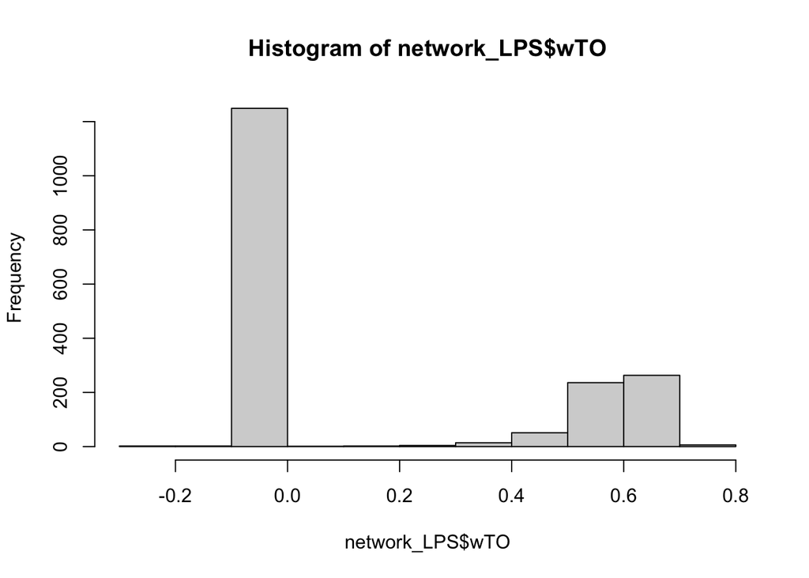

```r
hist(network_LPS$wTO)
```

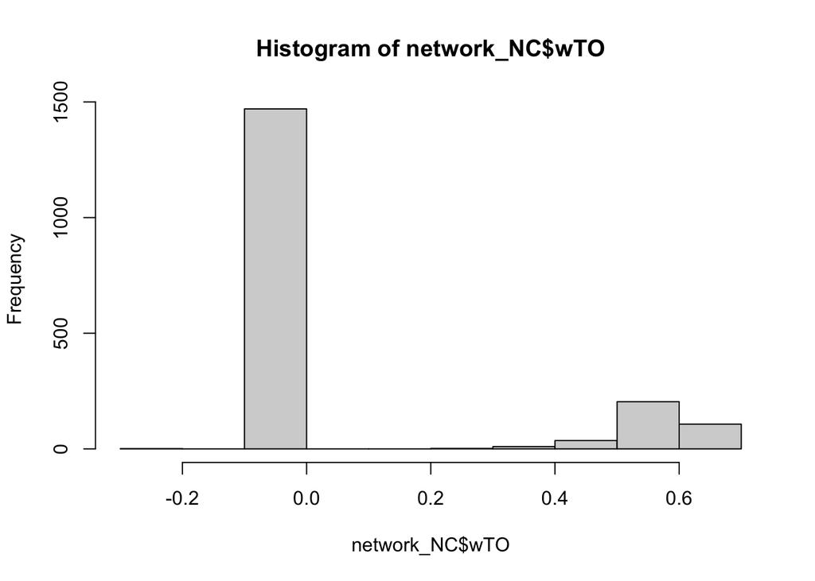

```r
hist(network_NC$wTO)
```

## Comparing networks with CoDiNA

We will now compare the TF wTO networks for NC and LPS. Load the `CoDiNA` package.

```r
require(CoDiNA)
```

The function `MakeDiffNet()` for comparing networks needs a list of the networks to be compared and the Code (= the name of each network). The node names need to be converted to characters before.

```r
network_NC$Node.1 = as.character(network_NC$Node.1)
network_NC$Node.2 = as.character(network_NC$Node.2)

Diff_LPS_NC = MakeDiffNet(Data = list(network_NC, network_LPS),
                          Code = c('NC', 'LPS'))
```

```
## Starting now.
```

```
## NC contains 1830 edges and 61 nodes.
```

```
## LPS contains 1830 edges and 61 nodes.
```

```
## Total of nodes: 61
```

```
## Total of edges: 1830
```

```
## Coding correlations.
```

```
## Total of edges (inside the cutoff): 843
```

```
## Starting Phi categorization.
```

```
## Coding the groups.
```

```
## Recode is done!
```

The resulting object, `Diff_LPS_NC` contains the information on the number of nodes and links in the differential network. It also contains the category of each link, it’s subcategory and the scores. To look at the table with that information, you can use the function `View()`.

```r
Diff_LPS_NC
```

| Node.1 | Node.2 | NC | LPS | Phi | Phi_tilde | Group | Score_center | Score_Phi | Score_Phi_tilde | Score_internal | Score_ratio |
| --- | --- | --- | --- | --- | --- | --- | --- | --- | --- | --- | --- |
| HES4 | MYSM1 | 0.88432268 | 0.0000000 | g | g.NC | +NC,NoLPS | 0.8843227 | 0.82586740 | 0.82117647 | 0.115677321 | 7.0988545 |
| DZIP1L | HES4 | 0.89497717 | 0.0000000 | g | g.NC | +NC,NoLPS | 0.8949772 | 0.84190593 | 0.83764706 | 0.105022831 | 7.9758568 |
| BCL6 | HES4 | 0.76255708 | 0.0000000 | g | g.NC | +NC,NoLPS | 0.7625571 | 0.64256993 | 0.63294118 | 0.237442922 | 2.6656561 |
| HES4 | NFKB1 | 0.00000000 | -0.3626062 | g | g.LPS | NoNC,-LPS | 0.3626062 | 0.04051173 | 0.04051173 | 0.637393768 | 0.0635584 |
| CD36 | HES4 | 0.86453577 | 0.0000000 | g | g.NC | +NC,NoLPS | 0.8645358 | 0.79608156 | 0.79058824 | 0.135464231 | 5.8361401 |
| HES4 | TFEC | 0.77625571 | -0.0368272 | g | g.NC | +NC,NoLPS | 0.7771288 | 0.66450518 | 0.65546734 | 0.226754825 | 2.8906434 |
| HES4 | IRF1 | 0.87214612 | 0.0000000 | g | g.NC | +NC,NoLPS | 0.8721461 | 0.80753765 | 0.80235294 | 0.127853881 | 6.2755462 |
| HES4 | IRF9 | 0.80821918 | 0.0000000 | g | g.NC | +NC,NoLPS | 0.8082192 | 0.71130648 | 0.70352941 | 0.191780822 | 3.6684034 |
| HES4 | NKX3-1 | 0.91324201 | 0.0000000 | g | g.NC | +NC,NoLPS | 0.9132420 | 0.86940055 | 0.86588235 | 0.086757991 | 9.9804334 |
| HES4 | ZNF740 | 0.71232877 | 0.0000000 | g | g.NC | +NC,NoLPS | 0.7123288 | 0.56695972 | 0.55529412 | 0.287671233 | 1.9303081 |

[output cut: 833 more lines]

```r
View(Diff_LPS_NC)
```

We can filter the data for the well-assigned AND strong links. These are links with a high ratio of the two scores, Phi_tilde and internal. Phi_tilde is a measure for how central a link is. Links closer to the center of the cube are weaker than links closer to the edges. The internal score measures the distance from the link weights $\rho_{ij, k}$ to their categorical weights $\widetilde\rho_{ij, k}$. In other words, in a 3-networks comparison, if a link is considered an alpha with positive links in all networks (1,1,1), we calculate its distance to the point (1,1,1). A beta link that has a $\tilde\rho$ of $\left(1,1,-1\right)$ has its distance calculated to the point $\left(1,1,-1\right)$. And for a gamma link with $\tilde\rho$ of (0,1,1) the distance is calculated to (0,1,1). This score allows us to identify links that are most well classified into a particular phi_tilde category.

```r
Diff_LPS_NC_clean = subset(Diff_LPS_NC,
                           Diff_LPS_NC$Score_Phi_tilde/Diff_LPS_NC$Score_internal > 1)
Diff_LPS_NC_clean
```

| Node.1 | Node.2 | NC | LPS | Phi | Phi_tilde | Group | Score_center | Score_Phi | Score_Phi_tilde | Score_internal | Score_ratio |
| --- | --- | --- | --- | --- | --- | --- | --- | --- | --- | --- | --- |
| HES4 | MYSM1 | 0.88432268 | 0.0000000 | g | g.NC | +NC,NoLPS | 0.8843227 | 0.8258674 | 0.8211765 | 0.115677321 | 7.098854 |
| DZIP1L | HES4 | 0.89497717 | 0.0000000 | g | g.NC | +NC,NoLPS | 0.8949772 | 0.8419059 | 0.8376471 | 0.105022831 | 7.975857 |
| BCL6 | HES4 | 0.76255708 | 0.0000000 | g | g.NC | +NC,NoLPS | 0.7625571 | 0.6425699 | 0.6329412 | 0.237442922 | 2.665656 |
| CD36 | HES4 | 0.86453577 | 0.0000000 | g | g.NC | +NC,NoLPS | 0.8645358 | 0.7960816 | 0.7905882 | 0.135464231 | 5.836140 |
| HES4 | TFEC | 0.77625571 | -0.0368272 | g | g.NC | +NC,NoLPS | 0.7771288 | 0.6645052 | 0.6554673 | 0.226754825 | 2.890643 |
| HES4 | IRF1 | 0.87214612 | 0.0000000 | g | g.NC | +NC,NoLPS | 0.8721461 | 0.8075377 | 0.8023529 | 0.127853881 | 6.275546 |
| HES4 | IRF9 | 0.80821918 | 0.0000000 | g | g.NC | +NC,NoLPS | 0.8082192 | 0.7113065 | 0.7035294 | 0.191780822 | 3.668403 |
| HES4 | NKX3-1 | 0.91324201 | 0.0000000 | g | g.NC | +NC,NoLPS | 0.9132420 | 0.8694006 | 0.8658824 | 0.086757991 | 9.980433 |
| HES4 | ZNF740 | 0.71232877 | 0.0000000 | g | g.NC | +NC,NoLPS | 0.7123288 | 0.5669597 | 0.5552941 | 0.287671233 | 1.930308 |
| HES4 | IKZF4 | 0.78995434 | 0.0000000 | g | g.NC | +NC,NoLPS | 0.7899543 | 0.6838119 | 0.6752941 | 0.210045662 | 3.214987 |

[output cut: 792 more lines]

### Classifying the nodes (genes) of the differential network

The function `ClusterNodes()` needs three parameters:  
The cleaned network (i.e. the network after the filtering above),  
The external cutoff (i.e. the minimum value for the `Score_Phi_tilde`; the closer you set this cutoff to one, the less nodes you will get),  
and the internal cutoff (i.e. the minimum value for the `Score_internal`; the closer you set this cutoff to zero, the less nodes you will get).  
Because our network is already filtered, we can use the external value as 0, and the internal as 1. This will make all nodes of the clean network to be clustered.

```r
DiffNodes = ClusterNodes(Diff_LPS_NC_clean,
                         cutoff.external = 0,
                         cutoff.internal = 1)
DiffNodes
```

| Node | Phi | pval_Phi | Group_pval_Phi | Phi_tilde | pval_Phi_Tilde | Group_pval_Phi_tilde |
| --- | --- | --- | --- | --- | --- | --- |
| BATF | g | 2.467446e-05 | g | g.LPS | 1.202045e-04 | g.LPS |
| BATF3 | g | 4.320463e-08 | g | g.LPS | 9.357623e-14 | g.LPS |
| BCL6 | g | 4.066142e-08 | g | g.NC | 7.300711e-09 | g.NC |
| CD36 | g | 5.580984e-03 | g | U | 4.005592e-01 | g.LPS |
| CEBPA | g | 8.944732e-07 | g | g.NC | 2.646574e-09 | g.NC |
| CEBPB | g | 1.179784e-03 | g | U | 2.045472e-01 | g.LPS |
| CREB1 | g | 3.381273e-05 | g | g.NC | 1.320253e-08 | g.NC |
| CREB3 | g | 1.456022e-08 | g | g.LPS | 1.048843e-12 | g.LPS |
| CREB3L1 | g | 9.633570e-07 | g | g.NC | 3.775135e-11 | g.NC |
| DOT1L | U | 1.572992e-01 | g | U | 1.353353e-01 | g.NC |

[output cut: 46 more lines]

Representing results as barplot:

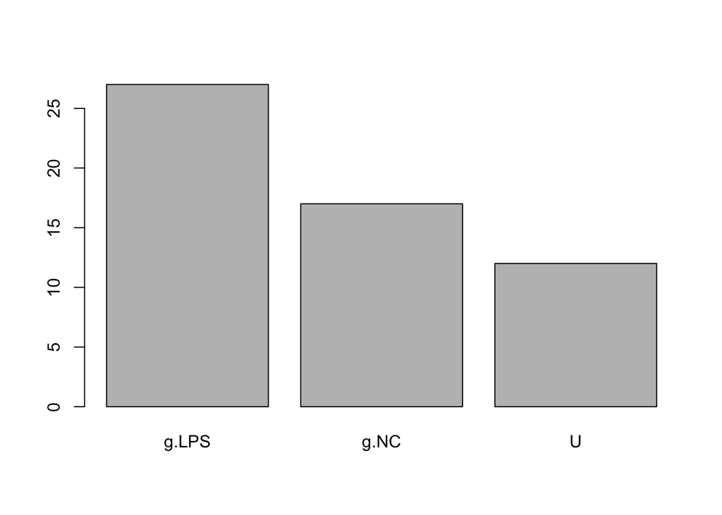

```r
barplot(table(DiffNodes$Phi_tilde))
```

Plotting the network. In this tutorial, the information used for making the plot is not printed. But it should show up on your screen. You can click on the nodes to see the `GeneSymbol` or filter for node categories.

```r
plot(Diff_LPS_NC_clean, layout = 'layout_with_drl')
```

If you see just a hairball, filter network before plotting. You can play around with the numbers for the external and internal cutoffs until you are satisfied with the number of nodes and links plotted. You should also see from the numbers on your screen that your network has fewer nodes and links.

```r
plot(Diff_LPS_NC_clean,
     cutoff.external = 0.8,
     cutoff.internal = 0.3,
     layout = 'layout_with_drl')
```

### Extracting information about nodes (genes) of each category

We can, for instance, subset for the common (alpha) nodes and for the nodes specific (gamma) to each network. The resulting information will be saved to a file.

```r
common_genes = subset(DiffNodes$Node, DiffNodes$Phi_tilde == 'a')
LPS_genes = subset(DiffNodes$Node, DiffNodes$Phi_tilde == 'g.LPS')
NC_genes = subset(DiffNodes$Node, DiffNodes$Phi_tilde == 'g.NC')

length(common_genes)
```

```
## [1] 0
```

```r
length(LPS_genes)
```

```
## [1] 27
```

```r
length(NC_genes)
```

```
## [1] 17
```

```r
write.table(common_genes, 'CoDiNA_common.txt', quote = F, row.names = F)
write.table(NC_genes, 'CoDiNA_NC.txt', quote = F, row.names = F)
write.table(LPS_genes, 'CoDiNA_LPS.txt', quote = F, row.names = F)
```

### Exercise 3

3.1. Make a wTO network (one for NC and one for LPS) that has all differentially expressed genes as nodes taking into account only all differentially expressed genes. Compare the networks using `CoDiNA`. How many nodes are common, LPS specific, or NC specific? Save a list of their gene names.

# Gene Ontology (GO) Enrichment analysis

In this part, we will test if the differentially expressed genes are enriched for particular functional categories using GO enrichment analysis with the package `TopGO`. As a prerequisite, we will need to retrieve the GO ID information for all expressed genes and for DE genes with `biomaRt`. Then we can run a statistical test for enrichment.

## Getting GO information with biomaRt

Load the library `biomaRt` (if you haven’t done so before). Choose a `Mart` and a `Dataset` (the output is not printed in this tutorial). We can use the human gene annotation for rhesus macaque genes because of their close evolutionary relationship.

```r
listMarts()
ensembl=useMart("ensembl")
listDatasets(ensembl)
mart <- useDataset("hsapiens_gene_ensembl", useMart("ensembl"))
```

We already got the list of all expressed genes before. It’s in the variable GeneSymbols. We want the gene symbols (column 2) and still need to remove duplicates from it using `unique()`.

```r
head (GeneSymbols)
```

|  | ensembl_gene_id | external_gene_name |
| --- | --- | --- |
| 1 | ENSMMUG00000000009 | PTPRC |
| 2 | ENSMMUG00000000015 | C1H1orf100 |
| 3 | ENSMMUG00000000016 | ADSS2 |
| 4 | ENSMMUG00000000021 | CATSPERE |
| 5 | ENSMMUG00000000037 | ISG20L2 |
| 6 | ENSMMUG00000000038 | METTL25B |

```r
dim(GeneSymbols)
```

```
## [1] 15371     2
```

```r
uniqGenesymbols = unique(GeneSymbols[,2])
head(uniqGenesymbols)
```

```
## [1] "PTPRC"      "C1H1orf100" "ADSS2"      "CATSPERE"   "ISG20L2"
## [6] "METTL25B"
```

```r
length(uniqGenesymbols)
```

```
## [1] 13246
```

```r
GeneGONames = getBM(filters= "hgnc_symbol", attributes= c("hgnc_symbol", "go_id"),values=uniqGenesymbols, mart= mart)
```

## Enrichment analysis with TopGO

Load the library `TopGO`.

```r
library("topGO")
```

To create a `topGOdata` object for the enrichment analysis we need a list of all genes, the significant genes, and the Genes2GO mapping. The list of all genes is contained in the `uniqGenesymbols` from above. The `DE_genes` are still in Ensembl IDs, so we need to retrieve their gene symbols. This could again be done with `Biomart` or by subsetting from `GeneSymbols`, which we will do here.

```r
head(GeneSymbols)
```

|  | ensembl_gene_id | external_gene_name |
| --- | --- | --- |
| 1 | ENSMMUG00000000009 | PTPRC |
| 2 | ENSMMUG00000000015 | C1H1orf100 |
| 3 | ENSMMUG00000000016 | ADSS2 |
| 4 | ENSMMUG00000000021 | CATSPERE |
| 5 | ENSMMUG00000000037 | ISG20L2 |
| 6 | ENSMMUG00000000038 | METTL25B |

```r
DEGenesymbols = subset(GeneSymbols, GeneSymbols$ensembl_gene_id %in% DE_genes)
uniqDEGenesymbols = unique(DEGenesymbols[,2])
length(uniqDEGenesymbols)
```

```
## [1] 690
```

TopGo now wants the gene lists combined and in a particular format (i.e. a named vector). This is what the next two code lines will do.

```r
geneList = factor(as.integer(uniqGenesymbols %in% uniqDEGenesymbols))
names(geneList) = uniqGenesymbols
str(geneList)
```

```
##  Factor w/ 2 levels "0","1": 1 1 1 1 1 1 1 1 2 1 ...
##  - attr(*, "names")= chr [1:13246] "PTPRC" "C1H1orf100" "ADSS2" "CATSPERE" ...
```

We also need to reformat the Genes2GO mapping for TopGo into the right format (i.e. a named list of character vectors). We first test the reformating for the first row of the table:

```r
GeneGONames[GeneGONames[,1]=="PDPN",1:2]
```

|  | hgnc_symbol | go_id |
| --- | --- | --- |
| 56056 | PDPN | GO:0005737 |
| 56057 | PDPN | GO:0005886 |
| 56058 | PDPN | GO:0016020 |
| 56059 | PDPN | GO:0031410 |
| 56060 | PDPN | GO:0043066 |
| 56061 | PDPN | GO:0042995 |
| 56062 | PDPN | GO:0005739 |
| 56063 | PDPN | GO:0005829 |
| 56064 | PDPN | GO:0070161 |
| 56065 | PDPN | GO:0016324 |

[output cut: 38 more lines]

Now we reformat the entire table and save the reformated table into a file. This takes some seconds.

```r
Genes2GO = matrix(,length(uniqGenesymbols),2)
for (i in 1:length(uniqGenesymbols))
{
  temp=GeneGONames[GeneGONames[,1]==uniqGenesymbols[i],1:2]
  tempGOs = paste(temp[,2], collapse=",")
  Genes2GO[i,1]=temp[1,1]
  Genes2GO[i,2]=tempGOs
}
write.table(Genes2GO, "Genes2Go.txt", quote=FALSE, row.names=FALSE, col.names=FALSE, se="\t")
Genes2GOmap=readMappings(file = "Genes2Go.txt")
str(head(Genes2GOmap))
```

```
## List of 6
##  $ PTPRC   : chr [1:98] "GO:0004725" "GO:0050852" "GO:0005515" "GO:0005886" ...
##  $ NA      : chr(0)
##  $ ADSS2   : chr [1:21] "GO:0005737" "GO:0005525" "GO:0000166" "GO:0004019" ...
##  $ CATSPERE: chr [1:10] "" "GO:0036128" "GO:0005886" "GO:0016020" ...
##  $ ISG20L2 : chr [1:13] "" "GO:0003676" "GO:0000175" "GO:0005634" ...
##  $ METTL25B: chr [1:5] "GO:0000179" "GO:0008649" "GO:0000154" "GO:0016020" ...
```

Now we can build the `topGOdata` object. In this example, we will test for Molecular Functions (MF). It will take a few seconds.

```r
GOdata = new("topGOdata", ontology = "MF", allGenes = geneList, annot = annFUN.gene2GO, gene2GO = Genes2GOmap)
```

```
##
## Building most specific GOs .....
```

```
##  ( 4166 GO terms found. )
```

```
##
## Build GO DAG topology ..........
```

```
##  ( 4549 GO terms and 5933 relations. )
```

```
##
## Annotating nodes ...............
```

```
##  ( 12252 genes annotated to the GO terms. )
```

The `topGOdata` object holds information about the ontology to analyze, number of genes and DE genes. Note that not all genes have GO information, which is why the number of feasible genes is smaller. Also the information about the GO graph is contained in the `topGOdata` object:

```r
GOdata
```

```
##
## ------------------------- topGOdata object -------------------------
##
##  Description:
##    -
##
##  Ontology:
##    -  MF
##
##  13246 available genes (all genes from the array):
##    - symbol:  PTPRC C1H1orf100 ADSS2 CATSPERE ISG20L2  ...
##    - 690  significant genes.
##
##  12252 feasible genes (genes that can be used in the analysis):
##    - symbol:  PTPRC ADSS2 ISG20L2 METTL25B MRPL24  ...
##    - 660  significant genes.
##
##  GO graph (nodes with at least  1  genes):
##    - a graph with directed edges
##    - number of nodes = 4549
##    - number of edges = 5933
##
## ------------------------- topGOdata object -------------------------
```

### Performing enrichment test

Here we will perform a Fisher’s exact test, but other enrichment tests can also be performed. The created object will hold the significant GO groups among other information.

```r
resultFisher = runTest(GOdata, algorithm = "classic", statistic = "fisher")
```

```
##
##           -- Classic Algorithm --
##
##       the algorithm is scoring 1308 nontrivial nodes
##       parameters:
##           test statistic: fisher
```

```r
resultFisher
```

```
##
## Description:
## Ontology: MF
## 'classic' algorithm with the 'fisher' test
## 4549 GO terms scored: 72 terms with p < 0.01
## Annotation data:
##     Annotated genes: 12252
##     Significant genes: 660
##     Min. no. of genes annotated to a GO: 1
##     Nontrivial nodes: 1308
```

Collecting the significant GO groups:

```r
sigterms = resultFisher@geneData["SigTerms"]
sigterms
```

```
## SigTerms
##     1308
```

```r
sigGOIDs = GenTable(GOdata, classicFisher = resultFisher, topNodes = sigterms)
head(sigGOIDs)
```

|  | GO.ID | Term | Annotated | Significant | Expected | classicFisher |
| --- | --- | --- | --- | --- | --- | --- |
| 1 | GO:0005126 | cytokine receptor binding | 165 | 35 | 8.89 | 1.7e-12 |
| 2 | GO:0005125 | cytokine activity | 119 | 29 | 6.41 | 3.8e-12 |
| 3 | GO:0005102 | signaling receptor binding | 964 | 95 | 51.93 | 3.7e-09 |
| 4 | GO:0140375 | immune receptor activity | 96 | 21 | 5.17 | 2.9e-08 |
| 5 | GO:0042379 | chemokine receptor binding | 32 | 12 | 1.72 | 4.5e-08 |
| 6 | GO:0048018 | receptor ligand activity | 250 | 36 | 13.47 | 6.0e-08 |

Correcting for multiple testing with Benjamini-Hochberg method and collecting only the most extreme groups:

```r
qval = p.adjust(sigGOIDs$classicFisher, met='BH')
sigGOIDscorrected = cbind(sigGOIDs, qval)
head(sigGOIDscorrected, n=30)
```

|  | GO.ID | Term | Annotated | Significant | Expected | classicFisher | qval |
| --- | --- | --- | --- | --- | --- | --- | --- |
| 1 | GO:0005126 | cytokine receptor binding | 165 | 35 | 8.89 | 1.7e-12 | 2.223600e-09 |
| 2 | GO:0005125 | cytokine activity | 119 | 29 | 6.41 | 3.8e-12 | 2.485200e-09 |
| 3 | GO:0005102 | signaling receptor binding | 964 | 95 | 51.93 | 3.7e-09 | 1.613200e-06 |
| 4 | GO:0140375 | immune receptor activity | 96 | 21 | 5.17 | 2.9e-08 | 9.483000e-06 |
| 5 | GO:0042379 | chemokine receptor binding | 32 | 12 | 1.72 | 4.5e-08 | 1.177200e-05 |
| 6 | GO:0048018 | receptor ligand activity | 250 | 36 | 13.47 | 6.0e-08 | 1.308000e-05 |
| 7 | GO:0030546 | signaling receptor activator activity | 256 | 36 | 13.79 | 1.1e-07 | 2.055429e-05 |
| 8 | GO:0030545 | signaling receptor regulator activity | 271 | 37 | 14.60 | 1.6e-07 | 2.616000e-05 |
| 9 | GO:0008009 | chemokine activity | 24 | 10 | 1.29 | 1.9e-07 | 2.761333e-05 |
| 10 | GO:0038023 | signaling receptor activity | 733 | 71 | 39.49 | 8.3e-07 | 9.869455e-05 |

[output cut: 20 more lines]

Finally, we can plot a GO graph for the most significant GO groups. This will require the package `Rgraphviz`.

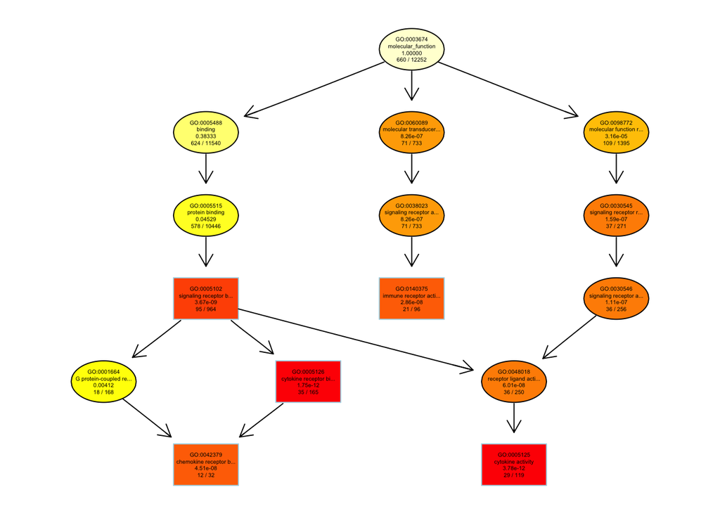

```
## $dag
## A graphNEL graph with directed edges
## Number of Nodes = 15
## Number of Edges = 16
##
## $complete.dag
## [1] "A graph with 15 nodes."
```

```r
library("Rgraphviz")
showSigOfNodes(GOdata, score(resultFisher), firstSigNodes = 5, useInfo = 'all')
```

### Excercise 4

4.1. Perform the Gene Ontology Enrichment analysis for the ontology “Biological Process (BP”)

## Submission of your tutorial

Please submit your script containing codes for exercises in the [FU box](https://box.fu-berlin.de/s/naQ4TKN6Xz4WgAs)

- Name of your script (.r/.rmd): 1_Givenname_Surname_MatrikelNr
- Please indicate in the script which tutorial you’re submitting, e.g. tutorial day 1
- Please indicate in the script the exercise number, e.g. 1-1
- Please comment your code, e.g. To retrieve x, function y